# The ships’ template

Our game will revolve around two ships fighting each other. So a natural starting point is to build them.

We want to create a template to produce ships of any shape. They’ll all have a floor, rooms and doors that affect the units’ pathfinding. We also have walls, but they’re purely visual.

In this lesson, we’ll build the *ShipTemplate* scene. It’s a base we’ll later extend to create the player and enemy ships.

Here’s an example of a complete ship based on this template.

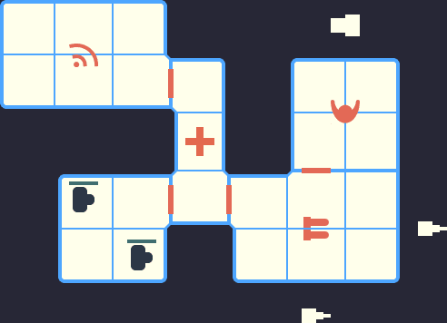

Conceptually, we make the ship out of rooms and doors floating in outer space. We’ll model this using the

[figure not shown]

`TileMap` node.

The rooms are rectangular and have adjustable width and height. We’ll place them manually to create the walkable area. We’ll also place the doors and separation walls manually since adjacent rooms can have more than one connecting door.

## Creating the template’s skeleton

Let’s start with the scene’s skeleton. Create a new

[figure not shown]

`Node2D` scene with its root named *ShipTemplate* and the following children:

- A

[figure not shown]

  `TileMap`.
- A

[figure not shown]

  `Node2D` named *Rooms*.
- A

[figure not shown]

  `Node2D` named *Doors*.
- A

[figure not shown]

  `Node2D` named *Walls*.

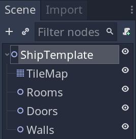

Set the

[figure not shown]

`TileMap` *Tile Set* property to the provided `res://TacticalSpaceCombat/Assets/ShipTileSet.tres` file. We’re providing an assets atlas made to work well with the default settings on the

[figure not shown]

`TileMap` node.

That’ll be all for setting up this node, as we’re using the default *Cell -> Size* of `64` by `64`.

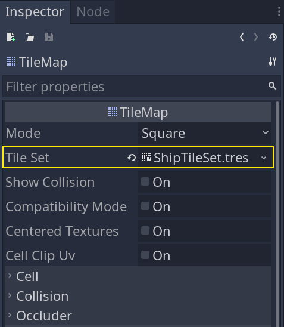

Save the *ShipTemplate* scene in `res://TacticalSpaceCombat/Ship/`.

To visualize the ships’ content, next, we’ll create the basic structure of the *Room*, *Door*, and *Wall* scenes.

### Creating a template for rooms

We start with *Room* by creating a new scene with the following scene tree:

- An

[figure not shown]

  `Area2D` named *Room*. We’ll use that area to detect units moving between rooms, doors inside a room, the enemy’s laser hitting, and to draw the appropriate tiles on the ships’

[figure not shown]

  `TileMap`.
- Another

[figure not shown]

  `Area2D` as a child named *HitArea2D*. We’ll use it to detect enemy projectiles hitting the room.
- You also want to add a

[figure not shown]

  `CollisionShape2D` as a child of each area.

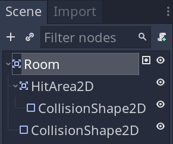

Let’s start by setting up the *Room* node.

Select the *Room* node and add it to the `room` group in the *Node -> Groups* dock.

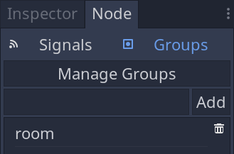

That’ll allow us to filter rooms from other areas in our code. Ideally, we’d do that with type checks, using the `is` operator: `area is Room`. But Godot 3 suffers from a problem when dealing with circular reference of class names, which gets in the way.

That’s why in this project, we’ll use groups to distinguish between node types, with calls like `area.is_in_group('room')`.

Then, select the *Room*’s

[figure not shown]

`CollisionShape2D` and in the *Inspector*, add a

[figure not shown]

`RectangleShape2D` to its *Shape*. You can set the shape’s *Extents* to `Vector2(32, 32)`, which will make it match the cell size we’ll use for our tilemaps, 64 by 64 pixels.

Make sure *Shape -> Resource -> Local To Scene* is on. Otherwise, changing the *Extents* on one

[figure not shown]

`CollisionShape2D` will change it for all rooms we’ll create later on.

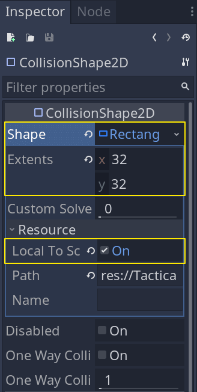

This is how resources work by default in Godot, we have to explicitly tell it that we require unique resources or it’ll will try to save resources by using the same resource everywhere.

Now, we select the *HitArea2D -> CollisionShape2D* node and set its *Shape* to a new

[figure not shown]

`CircleShape2D`. We keep the default *Radius* of `10` pixels. This area will detect hits from enemy rockets.

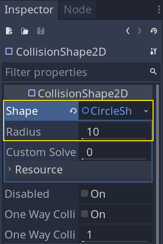

You can save the scene to `res://TacticalSpaceCombat/Ship/Rooms/Room.tscn`. We’ll try to keep everything organized as we move along.

### Doors

Next up are doors. They’ll detect units getting close to them and automatically open and close.

Their state will also influence the loss of oxygen, which will propagate to neighboring rooms with open doors.

Create a new scene with the following structure:

- An

[figure not shown]

  `Area2D` at the root named *Door*.
  - A

[figure not shown]

    `CollisionShape2D`.
  - A

[figure not shown]

    `Sprite` to draw the door.

[figure not shown]

As we did for the *Room*, add the *Door* node to the `door` group in the *Node -> Groups* dock.

For the

[figure not shown]

`Sprite`, we’ll use the project’s sprite atlas, which we’ll reuse for all other nodes.

Assign `res://TacticalSpaceCombat/Assets/Assets.svg` to the

[figure not shown]

`Sprite`’s *Texture*.

There are two door frames to represent it opened and closed.

You’ll want to turn on *Region -> Enabled* and set the region *Rect* to encompass both door sprites.

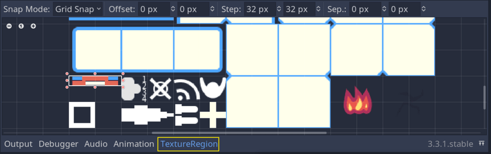

Finally, we set the *Animation -> Vframes* to `2`to split the image vertically into two halves.

This way, we get a frame for the closed door and another for the open door.

These *Hframes* and *Vframes* property take the texture region into account, so they’re be great when working with texture atlases.

Your *Inspector* should look like this.

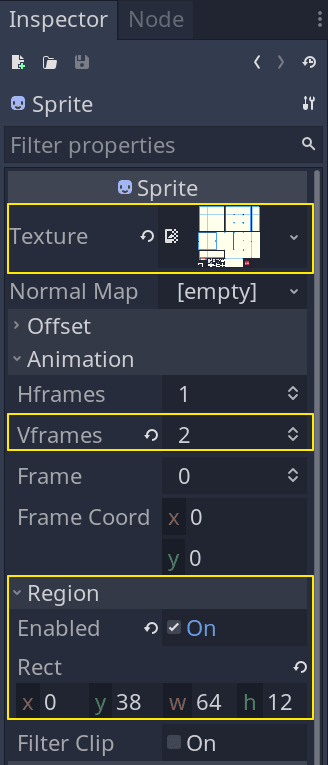

As for

[figure not shown]

`CollisionShape2D`, assign a

[figure not shown]

`RectangleShape2D` to its *Shape*.

Then set the *Shape*’s *Extents* to `Vector2(8, 16)`. The *Extents* value corresponds to our predefined tile size.

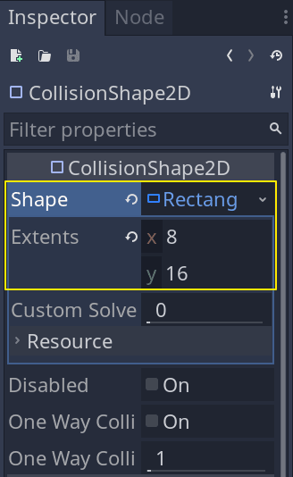

Finally, save the scene as `res://TacticalSpaceCombat/Ship/Rooms/Door.tscn`.

### Walls

In most cases, we’ll rely on the

[figure not shown]

`TileMap` node’s auto-tiling feature to draw the ship’s floor and walls.

However, when two rooms share a wall, we’ll need to draw it manually.

That’s why next, we’re creating a *Wall* scene.

These walls are only cosmetic, to visually separate rooms that share an edge.

Here’s an example with two rooms that require a manually-placed wall.

You have the editor’s view on the left, and the in-game result on the right. I added a yellow outline to help you spot it.

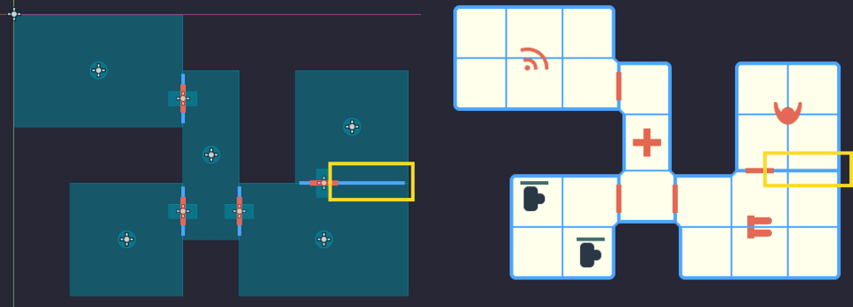

We could come up with a complex algorithm to automatically add walls to the appropriate places, but it’s not worth the time investment in this demo, where we’ll create ships manually.

Create a new scene with a

[figure not shown]

`Line2D` as root node and rename it to *Wall*. This node is the only one we need.

Set the following properties in the *Inspector*:

- Under *Points*, increase *Size* to `2` and for the point values use: `Vector2(-36, 0)` and `Vector2(28, 0)`. The reason this isn’t symmetrical is because of how I designed the game’s tilemap texture. You’ll see why below, when building your first ship.
- Set the *Width* to `4` pixels.
- And set the *Default Color* to `#4da6ff`. That’s the light blue tone from the color palette.

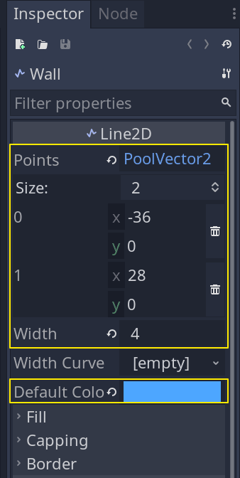

Save the scene at `res://TacticalSpaceCombat/Ship/Rooms/Wall.tscn`.

## Example ship configuration

Godot offers us some convenient ways to extend the editor to simplify our work.

It has a `tool` mode that lets us run our scripts directly in the editor. We’ll use this to our advantage to set up room properties that trigger node updates as we edit the scene.

For a thorough explanation of the `tool` mode, check out the official documentation on [running code in the editor](https://docs.godotengine.org/en/stable/tutorials/misc/running_code_in_the_editor.html).

### Coding the room

Open the *Room* scene and assign a script to the root node:

```
## Represents a room in the ship.
tool
class_name Room
extends Area2D

## Room size in `TileMap` cells.
# We'll use the setter function to resize the room's collision shapes.
export var size := Vector2.ONE setget set_size

# We store a reference to the ship's `TileMap` to convert from world to map
# positions and the other way around.
var _tilemap: TileMap = null

## We'll update this node with the `set_size()` setter function.
onready var collision_shape: CollisionShape2D = $CollisionShape2D
```

We start by adding the `tool` keyword at the top of the script. This makes the code run in the editor when we open the scene.

*Note* the use of `class_name`. We register this class at the global level under the name `Room`. It will come in handy for autocompletion and type checks later.

Next, we export the `size` variable. By exporting it, we’ll have access to it from the *Inspector*.

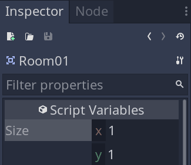

To get a reference to the ship’s

[figure not shown]

`TileMap`, we define a `setup()` function the ship will call.

Throughout the series, you’ll see this pattern come up often. We use it every time we need some information from a parent node.

```
## Initializes the room's properties in the `tilemap`'s coordinates.
func setup(tilemap: TileMap) -> void:
    _tilemap = tilemap
    _setup_extents()


func _setup_extents() -> void:
    # Since we run this code in the editor, we first make sure that `_tilemap`
    # is an actual reference to the `TileMap` node.
    if _tilemap != null:
        # `RectangleShape2D.extents` is half the desired rectangle's size.
        collision_shape.shape.extents = 0.5 * _tilemap.map_to_world(size)


## This setter function gets called whenever we change the _Size_ property
## in the _Inspector_.
func set_size(value: Vector2) -> void:
    # This operation ensures the size never goes below `Vector2(1, 1)`.
    for axis in [Vector2.AXIS_X, Vector2.AXIS_Y]:
        # We make sure to not let the value go below
        size[axis] = max(1, value[axis])
    # Every time we change the size, we update the collision shape's extents.
    _setup_extents()
```

### Passing the tilemap’s reference through the ship

To make this code do something in the editor, we need the

[figure not shown]

`TileMap` reference from the parent node.

Go back to the *ShipTemplate* scene and add a script to its root node with the following code:

```
tool
extends Node2D

onready var tilemap: TileMap = $TileMap
onready var rooms: Node2D = $Rooms


func _ready() -> void:
    for room in rooms.get_children():
        room.setup(tilemap)
```

*Note* that we added `tool` to this script as well. That’s because we need this script to call `room.setup()` when opening a ship’s scene in the editor.

### Constructing a ship

We now have all the components we need to design a ship. So we will create the player ship layout next.

We’ll work with an inherited scene based on `ShipTemplate.tscn`. We use this approach to keep the player ship in sync with changes to `ShipTemplate.tscn`. Later, we’ll use the same approach with the enemy AI’s ship.

The advantage of using inherited scenes is that if we change node properties in the parent scene, these changes propagate to the inherited scene to keep in sync with the parent file.

To get started, go to `Scene -> New Inherited Scene...` and select `ShipTemplate.tscn`.

A new unsaved scene tab opens for us. It has the scene tree populated with the structure from `ShipTemplate.tscn`, with grayed-out nodes.

We can change the properties of the gray nodes, but we can’t delete them: they are part of the parent scene.

Rename the root node to *ShipPlayer* to differentiate it and save the inherited scene at `res://TacticalSpaceCombat/Ship/ShipPlayer.tscn`.

Make sure to add *ShipPlayer* to the `player` group in the *Node -> Groups* dock.

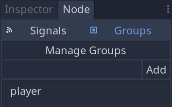

The group icon should appear next to the node.

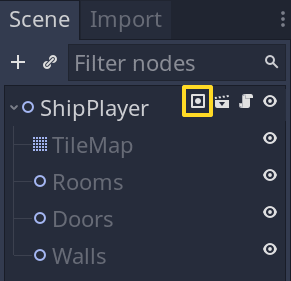

This group will be useful to check wether we’re dealing with the player ship or the enemey AI ship.

The following image shows a complete ship configuration with four rooms, three doors, and walls placed appropriately.

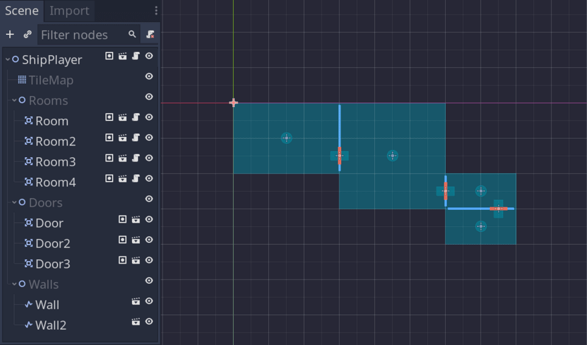

To design a ship, you want to create instances of the rooms, doors, and walls, then place them in the viewport.

To do so, we drag and drop `Room.tscn`, `Door.tscn`, and `Wall.tscn` onto the corresponding 2D nodes.

To accurately place the scenes, so it makes sense in our tile-based world, I invite you to enable grid snapping and configure it with 32-pixel steps. That’s half the cell size of our

[figure not shown]

`TileMap`.

We also set *Primary Line Every* to 2 steps.

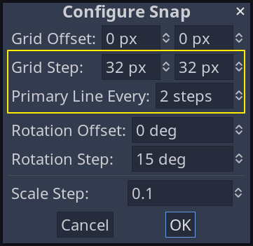

Then, click the *Use Grid Snap* icon to show the grid and turn on snapping.

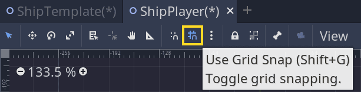

With *Primary Line Every* set to 2 steps, the viewport shows a grid with major lines every 64-pixels. That’s double our 32-pixel grid snap setting.

This will help us greatly in positioning the rooms in appropriate places since they have to match the

[figure not shown]

`TileMap` coordinates.

### Placing, rotating, and sizing elements

In a complete game, you would probably want to generate the ships procedurally, which would require a lot of experimentation (it can take weeks or months of work).

Procedural generation is beyond the scope of this series. Here, we’ll go the manual route.

Create a first room instance by clicking and dragging `Room.tscn` onto the *Rooms* node.

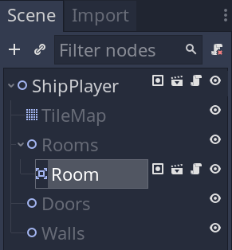

Right now, you can move it around the scene, but you can’t directly change its size, even though we exposed the *Size* property in the *Inspector*.

That’s because we call `room.setup()` from `_ready()` which gets triggered only once, when we open the ship scene file.

To trigger `_ready()`, save the file **after** you add your preferred number of *Room* nodes and click *Scene -> Reload Saved Scene* in the menu.

Be sure need to **first save** the scene before reloading. Otherwise, you’ll lose your changes.

This will reload the current scene and thus call `_ready()` which in turn runs `room.setup()` and the code from the *Room* scene.

If you now change the *Size* property on any *Room* that you added before reloading the scene, you’ll see it updating in the viewport.

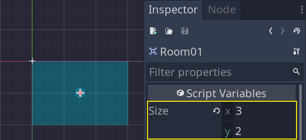

You want to reach a point where you have adjacent rooms aligned with the main grid lines, as in the following example.

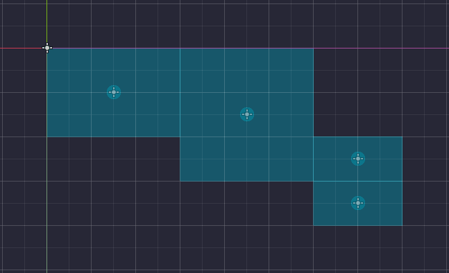

Double-check that all room edges align with the thicker grid lines. We need the position of the rooms to align with the

[figure not shown]

`TileMap`’s cells.

From there, you want to do the same with doors and walls. You want to create door instances and move and rotate them to stand between two rooms.

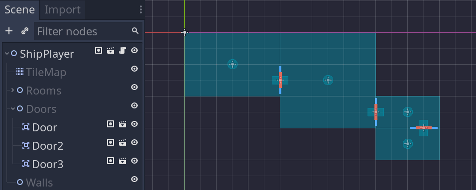

You need to be careful with placing the doors since they have to align with the tile-based world as well.

Units will walk through grid cells so if the door falls between two cells, units will be unable to cross them.

Doors should align with a grid cell’s edge as in the image above.

The image on the left shows a **wrong way** to place the door, while the one on the right shows the **correct alignment**.

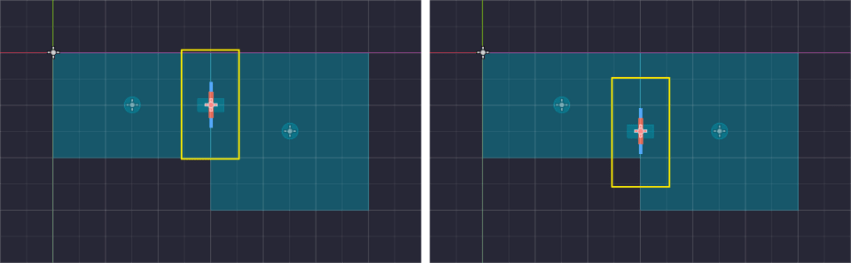

Next are the walls. They go in places where two rooms are adjacent to one another, and there is no door to cover the cell, as illustrated below.

Here is the complete ship template I created for this lesson.

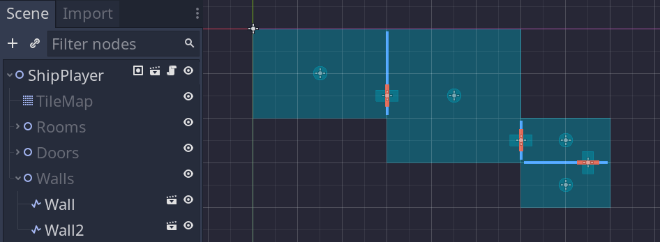

*Note* that you’ll have to rotate some walls 180 degrees so it makes sense given our `Assets.svg` atlas. The **correct rotation** of the wall is the one in the **right image**.

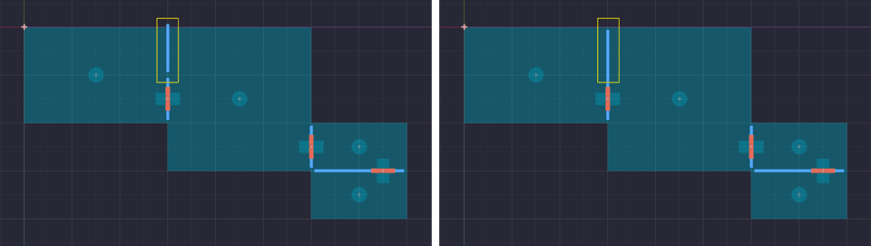

Make your ship as elaborate or as simple as you want, trying not to make it bigger than half the game window so we have enough space to render the enemy ship in front of it.

Anywhere between 3 and 6 rooms of up to about 200 pixels in width is a good size.

## Conclusion

In this lesson, we prepared a template to build and code the player and enemy ships. We already started testing things out for the player ship.

We explored ways to place our assets visually within the 2D viewport in an efficient manner. We also used the `tool` mode to run code in the editor to make our ship configuration easier.

At this point, we won’t see the actual ship graphics if we play the game, apart from the doors and walls.

That’s because we still have to draw tiles programmatically using

[figure not shown]

`TileMap` node. This will be the next lesson’s topic.

## Code reference

`res://TacticalSpaceCombat/Ship/Rooms/Room.gd`:

```
tool
extends Area2D

export var size := Vector2.ONE setget set_size

var _tilemap: TileMap = null

onready var collision_shape: CollisionShape2D = $CollisionShape2D


func setup(tilemap: TileMap) -> void:
    _tilemap = tilemap
    _setup_extents()


func _setup_extents() -> void:
    if _tilemap != null:
        collision_shape.shape.extents = 0.5 * _tilemap.map_to_world(size)


func set_size(value: Vector2) -> void:
    for axis in [Vector2.AXIS_X, Vector2.AXIS_Y]:
        size[axis] = max(1, value[axis])
    _setup_extents()
```

`res://TacticalSpaceCombat/Ship/ShipTemplate.gd`:

```
tool
extends Node2D

onready var tilemap: TileMap = $TileMap
onready var rooms: Node2D = $Rooms


func _ready() -> void:
    for room in rooms.get_children():
        room.setup(tilemap)
```